# Reproducible Research: Peer Assessment 1

## Loading and preprocessing the data

- Here we will load the data from the CSV file using the **read.csv()** function
- Unzip the file and read the CSV file in one line

```r
activity  <- read.csv(unz("activity.zip", "activity.csv") ,sep=",",na.strings='NA',header=TRUE)
```

## What is mean total number of steps taken per day?

- Remove the NA values

```r
activity_nona <- na.omit(activity)
```

- Aggregate the steps per day using **aggregate**

```r
activity_day_steps <- aggregate(steps ~ date, activity_nona, sum,na.rm = T)
```

- Create the hisogram of Total number of steps/day

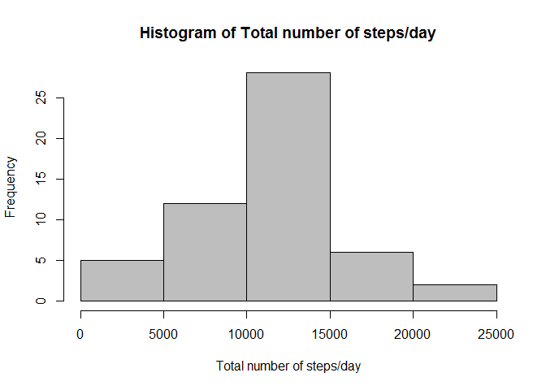

```r
hist(activity_day_steps$steps, col = "gray",
     xlab = "Total number of steps/day", main = "Histogram of Total number of steps/day")
```

- Calculate mean and median of total number of steps per day

```r
mean(activity_day_steps$steps, na.rm=TRUE)
```

```
## [1] 10766.19
```

```r
median(activity_day_steps$steps)
```

```
## [1] 10765
```

- The mean of total number of steps per day is **10766.19** .
- The median of total number of steps per day is **10765**.

## What is the average daily activity pattern?

- Aggregate the steps per interval using **aggregate**

```r
activity_interval_steps <- aggregate(steps ~ interval, activity, mean)
```

- Plot the time series plot using **type=1**

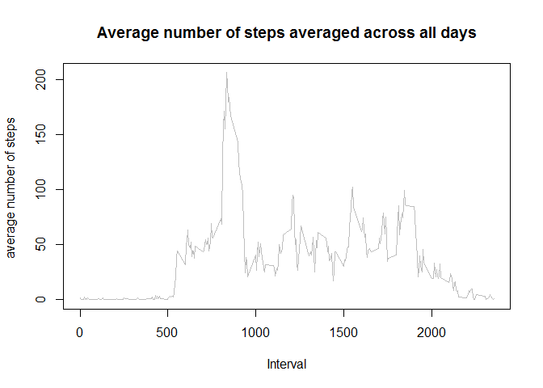

```r
plot(activity_interval_steps$interval, activity_interval_steps$steps, type='l', col = "gray",
     main="Average number of steps averaged across all days", xlab="Interval",
     ylab="average number of steps ")
```

- get the interval which has the maximum average of steps across all days

```r
max_interval <- activity_interval_steps[which.max(activity_interval_steps$steps),]
max_interval
```

```
##     interval    steps
## 104      835 206.1698
```